# (Ford GoBike)

## by (Shireen Talaat)

## Investigation Overview

Figuring out the average duration of trips, most common station, which gender, and what age uses the bikes more, and what day includes the highest bike rent. Therefore we can provide this right station with more appropriate bikes that suit the usage purpose.

## Dataset Overview

FordGoBike data has a size of (183412 x 16) that provides infomation about bike trips during Feb. 2019. Each trip is anonymized and includes:

- Trip Duration (seconds)
- Start Time and Date
- End Time and Date
- Start Station ID and Name.
- Start Station Latitude and Latitude.
- End Station ID and Name.
- End Station Latitude and Latitude
- Bike ID
- User Type (Subscriber or Customer – “Subscriber” = Member or “Customer” = Casual)

## Univariate Exploration

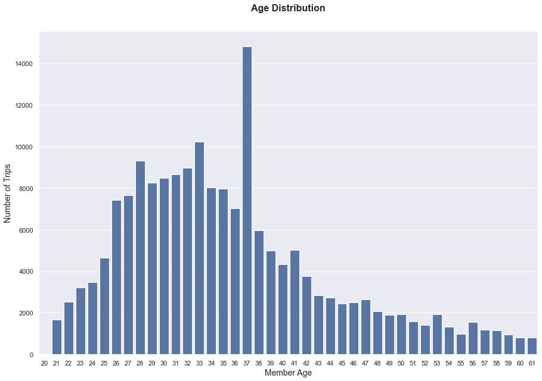

Age distribution is right skwed. The most common age is 37.

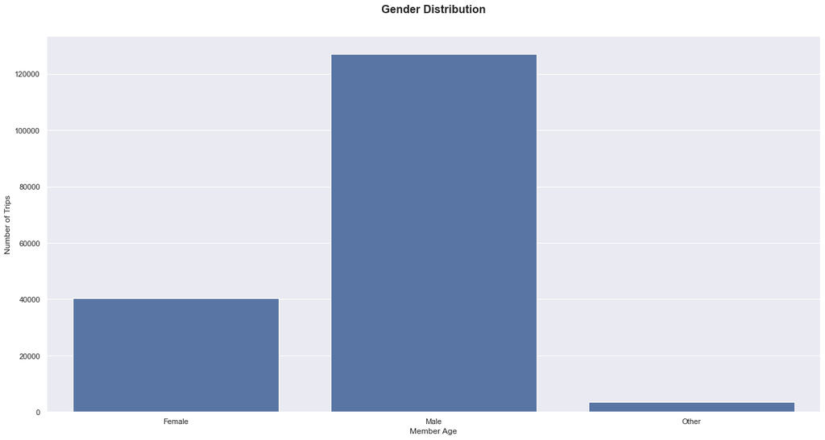

Male members are more than other genders.

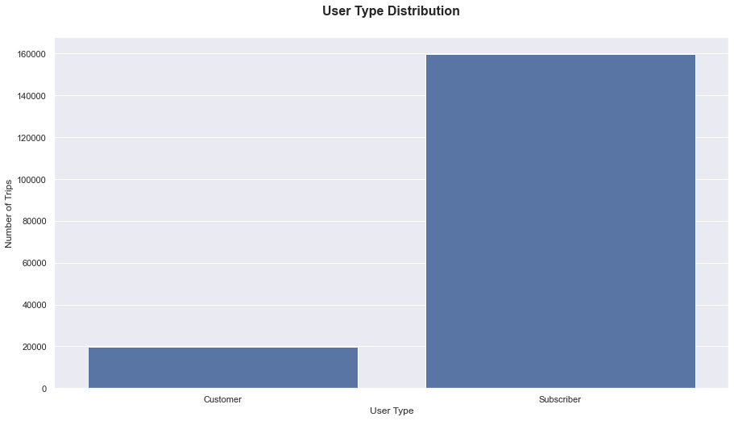

Subscribers are more than customers.

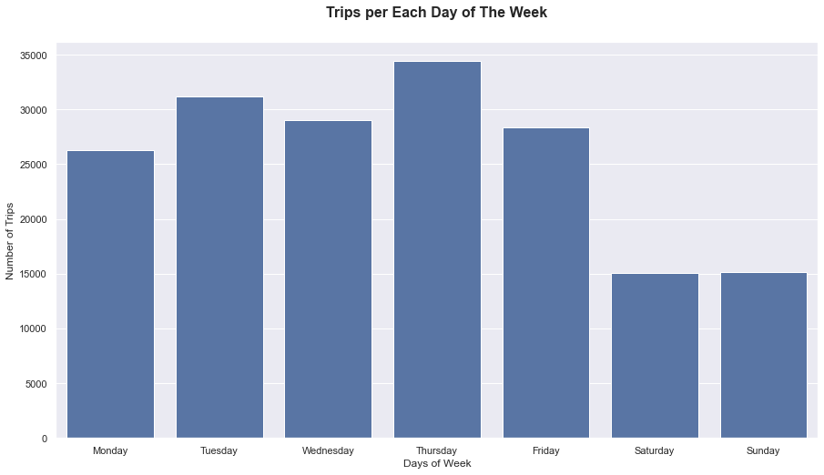

The day with the most trips is Thursday. Weekends have the least trips.

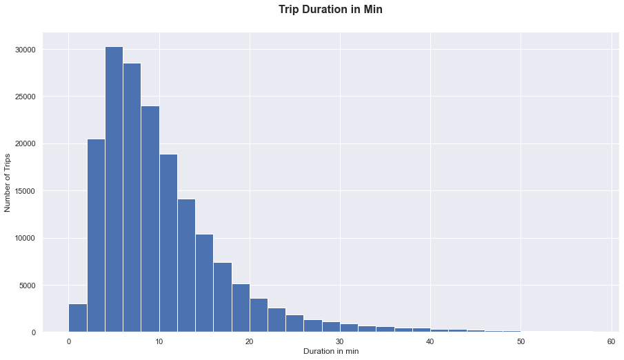

The average Trip Duration is between 6 and 12 mins.

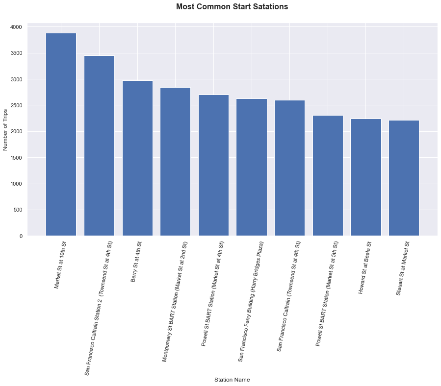

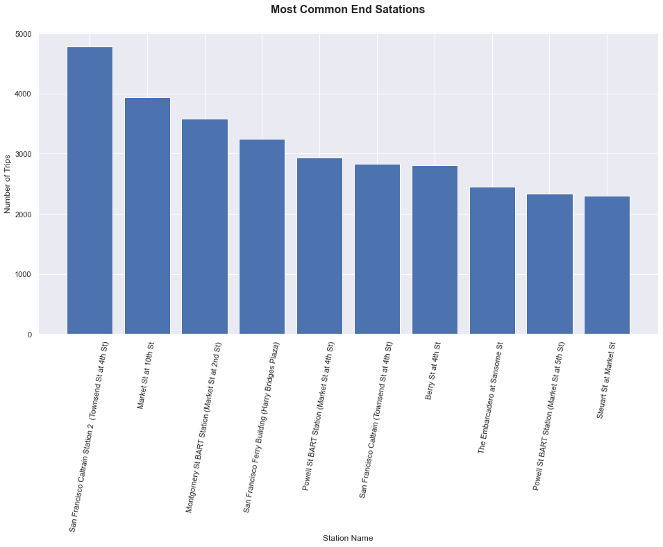

## Bivariate Exploration

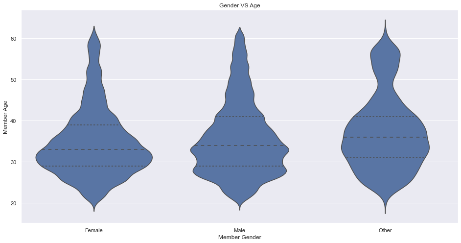

Most Female age is between 28 : 38, however most male age is between 28: 42.

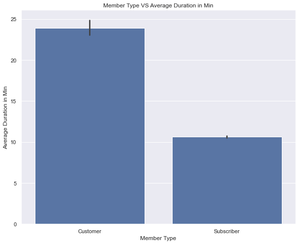

It seems that customers have longer trips than subscribers

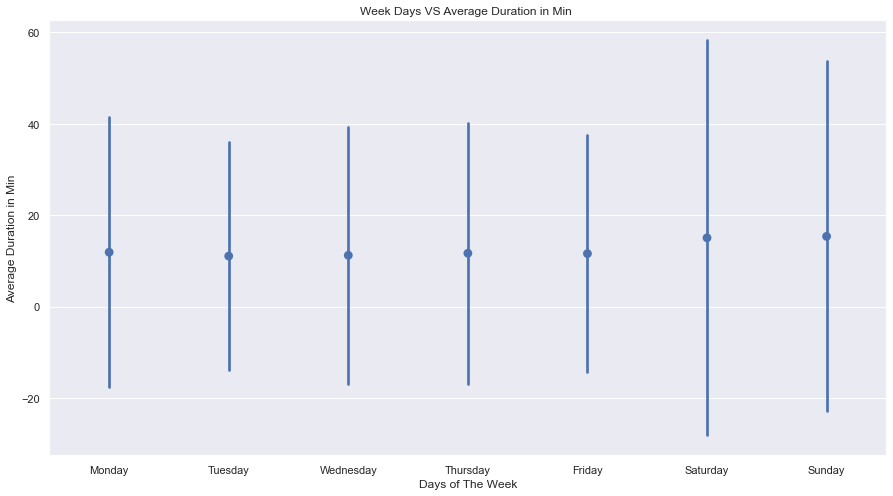

Trip duration is longer on weekends than week days

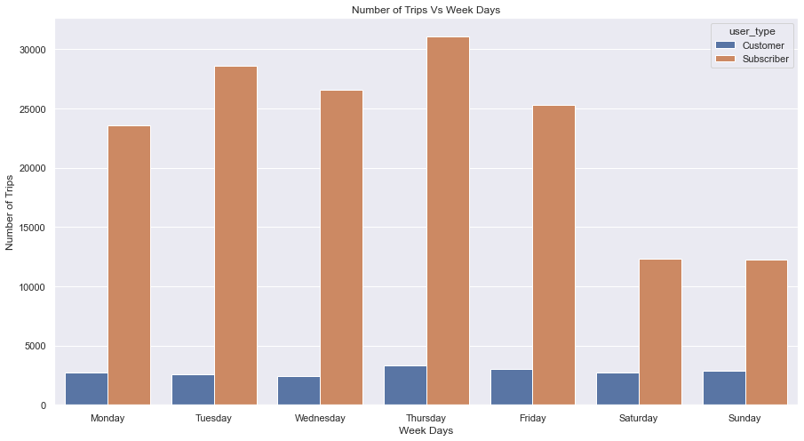

## Multivariate Exploration

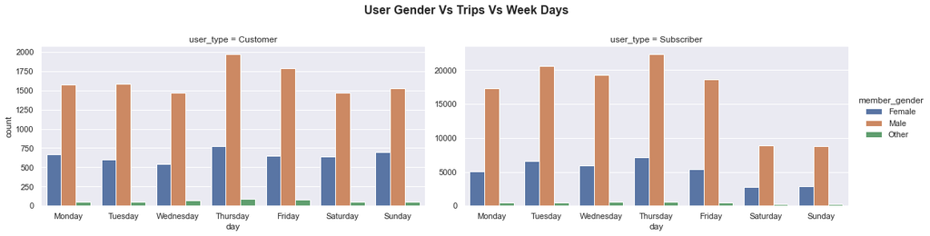

Both Genders have more Trips during week days than weekend.

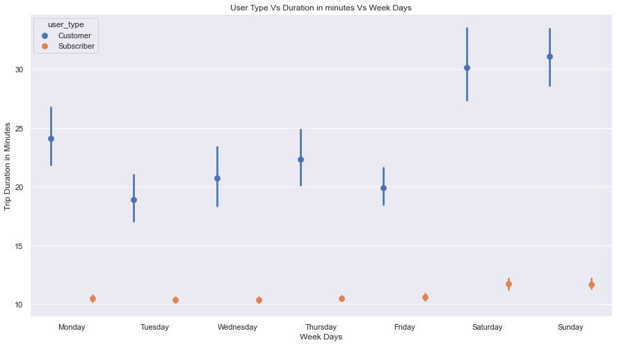

I can notice that customers have longer Trips than subscribers. Also Weekend Trips are longer than week days trips.

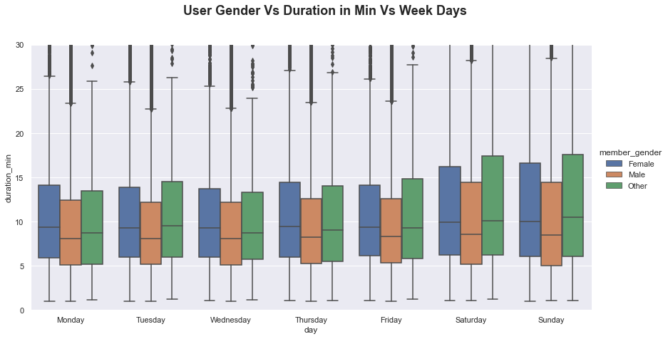

```
[NbConvertApp] Converting notebook slide_deck_template.ipynb to slides
[NbConvertApp] Writing 904345 bytes to slide_deck_template.slides.html
```